# Reproducible Research: Peer Assessment 1

## Loading and preprocessing the data

```r
df = read.csv("activity.csv", header = T)
# check the data frame structure
str(df)
```

```
## 'data.frame':    17568 obs. of  3 variables:
##  $ steps   : int  NA NA NA NA NA NA NA NA NA NA ...
##  $ date    : Factor w/ 61 levels "2012-10-01","2012-10-02",..: 1 1 1 1 1 1 1 1 1 1 ...
##  $ interval: int  0 5 10 15 20 25 30 35 40 45 ...
```

## What is mean total number of steps taken per day?

For this part of the assignment, you can ignore the missing values in the dataset.

Calculate the total number of steps taken per day

```r
steps_per_day = with(df,tapply(df$steps, as.factor(df$date), sum, na.rm=T))
```

Make a histogram of the total number of steps taken each day

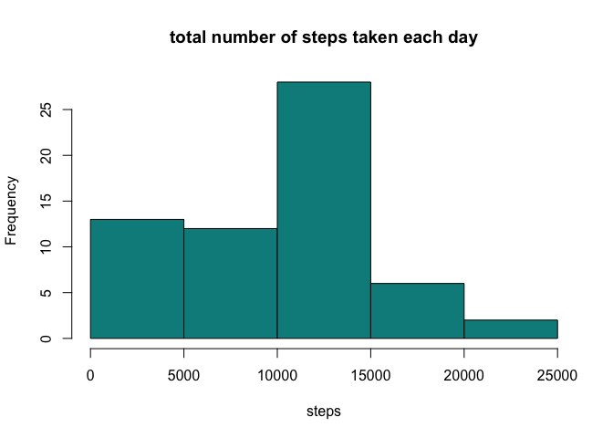

```r
hist(steps_per_day,
     main = "total number of steps taken each day",
     xlab = "steps",
     col = "cyan4")
```

Calculate and report the mean and median of the total number of steps taken per day

```r
print(paste("The mean of the total number of steps taken per day is:",as.character(mean(steps_per_day))))
```

```
## [1] "The mean of the total number of steps taken per day is: 9354.22950819672"
```

```r
print(paste("The median of the total number of steps taken per day is:",as.character(median(steps_per_day))))
```

```
## [1] "The median of the total number of steps taken per day is: 10395"
```

## What is the average daily activity pattern?

Make a time series plot (i.e. type = “l”) of the 5-minute interval (x-axis) and the average number of steps taken, averaged across all days (y-axis)

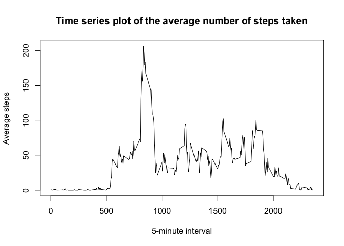

```r
average_steps = with(df, tapply(X = steps, INDEX = df$interval, FUN = mean,na.rm=T))
interval = levels(as.factor(df$interval))
plot(interval, average_steps, type = "l",
     main = "Time series plot of the average number of steps taken",
     xlab = "5-minute interval", ylab = "Average steps")
```

Which 5-minute interval, on average across all the days in the dataset, contains the maximum number of steps?

```r
print(interval[which.max(average_steps)])
```

```
## [1] "835"
```